# York and Diming Regression

Quan Gan

2/26/2022

## Load data in

There are three data sets with low, intermediate, and high errors.

```r
data_low <- read_csv("../Data/Dataset_S1_Mar8.csv")
data_intermediate <- read_csv("../Data/Dataset_S2_Mar8.csv")
data_high <- read_csv("../Data/Dataset_S3_Mar8.csv")
```

## The functions for bootstrapping 1000 replicates with York models

```r
# https://www.statmethods.net/advstats/bootstrapping.html
# Boot library docs
# calculate the Intercept
York_model <- function(formula, data, indices) {
  d <- data[indices,]                   # allows boot to select sample
  mark <- sample(                       # Mark for train-test
    c(rep(0, 0.7*nrow(d)),
    c(rep(1, 0.3*nrow(d)))))
  train <- d[mark == 0,]                # train data
  test <- d[mark == 1,]                 # test data
  york_data <- cbind(train$Temperature, train$TempError, train$D47, train$D47error)
  fit <- york(york_data)                # the York model
  Intercept <- fit$a['a']
  Slope <- fit$b['b']
  train_MSE <- mean((train$D47 - (train$Temperature * Slope + Intercept))^2)  # Train set MSE
  test_MSE <- mean((test$D47 - (test$Temperature * Slope + Intercept))^2) # Test set MSE
  return(c(Intercept, Slope, train_MSE, test_MSE))                    # get intercept
}

Deming_model <- function(formula, data, indices) {
  d <- data[indices,]                   # allows boot to select sample
  mark <- sample(                       # Mark for train-test
    c(rep(0, 0.7*nrow(d)),
    c(rep(1, 0.3*nrow(d)))))
  train <- d[mark == 0,]                # train data
  test <- d[mark == 1,]                 # test data
  fit <- deming(formula, data=train, xstd=abs(TempError), ystd=abs(D47error))    # the Deming model
  Intercept <- fit$coefficients[1]
  Slope <- fit$coefficients[2]
  train_MSE <- mean((train$D47 - (train$Temperature * Slope + Intercept))^2)  # Train set MSE
  test_MSE <- mean((test$D47 - (test$Temperature * Slope + Intercept))^2) # Test set MSE
  return(c(Intercept, Slope, train_MSE, test_MSE))                    # get intercept
}

model <- function(seed, statistic, dataSet, formula, replicate){
  set.seed(seed)
  results <- boot(data = dataSet,
                  statistic = statistic,
                  R = replicate,
                  formula = formula)

  CI_Intecept <- boot.ci(results, type="bca", index=1)
  Intercept_names <- c("Median Intercept", "Intercept Std. Error", "2.5%", "92.5%")
  Intercept_values <- c(median(results$t[,1]), sd(results$t[,1]) / sqrt(length(results$t[,1])), CI_Intecept$bca[4], CI_Intecept$bca[5])
  names(Intercept_values) <- Intercept_names

  CI_Slope <- boot.ci(results, type="bca", index=2)
  Slope_names <- c("Median Slope", "Slope Std. Error", "2.5%", "92.5%")
  Slope_values <- c(median(results$t[,2]), sd(results$t[,2]) / sqrt(length(results$t[,2])), CI_Slope$bca[4], CI_Slope$bca[5])
  names(Slope_values) <- Slope_names

  MSE_names <- c("Median Train MSE", "Median Test MSE")
  MSE_values <- c(median(results$t[,3]), median(results$t[,4]))
  names(MSE_values) <- MSE_names


  Intercept_values %>% kable()
  Slope_values %>% kable()
  MSE_values %>% kable()

  return (c(Intercept_values, Slope_values, MSE_values))
}

# create data visualization
createPlot <- function(data, result, title, caption) {
  plot_object <- data %>%
    ggplot(aes(x = x_TRUE, y=y_TRUE)) +
    geom_ribbon(aes(ymin = result[7] * x_TRUE + result[4] , ymax = result[8] * x_TRUE + result[3]), fill = "orange") +
    geom_point() +
    geom_abline(slope = 0.0369, intercept = 0.268, color = 'red') +
    geom_abline(slope = result[5], intercept = result[1], color = 'yellow') +
    labs(title = title,
         caption = paste(caption, "\n", greeks("alpha"), "=",round(result[1], 4), "(95% CI", round(result[3], 4),"-", round(result[4],4), ")\n"
         , greeks("beta"), "=",round(result[5], 4), "(95% CI", round(result[7], 4),"-", round(result[8],4), ")" ))+
    xlab(expression(paste("True Temperature in ", ""^"o", "K"))) +
    ylab(expression(paste("True D47 (", ""^"o", "/"["oo"], ")")))
  return(plot_object)
}
```

## York Regresion

Unified regression algorithm. Given n pairs of measurements of x and y with their uncertainties x_error, y_error. The york function finds the best straight line using the least-squares algorithm of York.

### Low error data

```r
york_result_low <- model(1234, York_model, data_low, D47~Temperature, 1000)

rbind(york_result_low) %>% kable()
```

|  | Median Intercept | Intercept Std. Error | 2.5% | 92.5% | Median Slope | Slope Std. Error | 2.5% | 92.5% | Median Train MSE | Median Test MSE |
| --- | --- | --- | --- | --- | --- | --- | --- | --- | --- | --- |
| york_result_low | 0.2583409 | 0.0003717 | 0.2504001 | 0.301751 | 0.0376571 | 2.41e-05 | 0.0349581 | 0.0382562 | 0.0001709 | 0.000171 |

#### Comparing result to the true parameters

Plot confident interval area of the median slope/intercept of bootstrapping results And comparing it to the true slope/intercept

I use the true data points to plot.

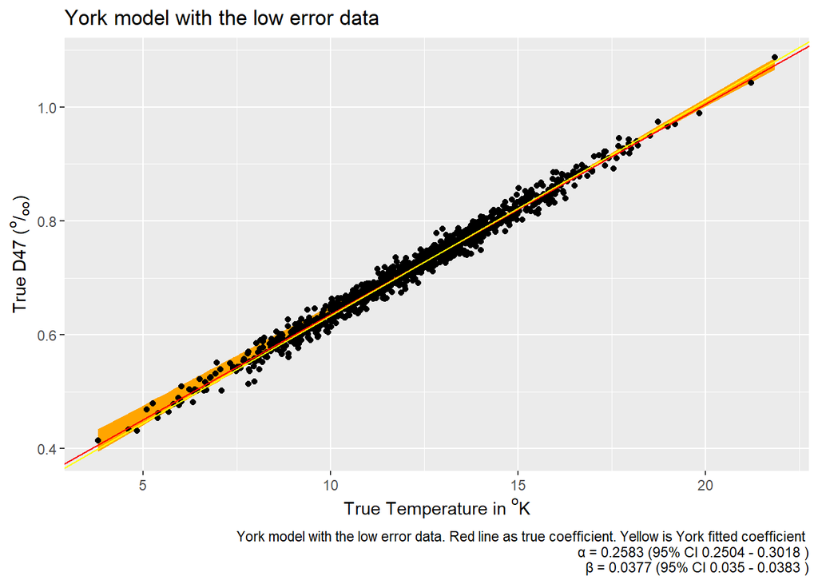

```r
createPlot(data_low,
           york_result_low,
           "York model with the low error data",
           "York model with the low error data. Red line as true coefficient. Yellow is York fitted coefficient")
```

### Intermediate error data

```r
york_result_intermediate <- model(1234, York_model, data_intermediate, D47~Temperature, 1000)

rbind(york_result_intermediate) %>% kable()
```

|  | Median Intercept | Intercept Std. Error | 2.5% | 92.5% | Median Slope | Slope Std. Error | 2.5% | 92.5% | Median Train MSE | Median Test MSE |
| --- | --- | --- | --- | --- | --- | --- | --- | --- | --- | --- |
| york_result_intermediate | 0.2545176 | 0.0008533 | 0.2357275 | 0.335303 | 0.0380324 | 5.45e-05 | 0.0326575 | 0.0391353 | 0.0006522 | 0.0006562 |

#### Comparing result to the true parameters

Plot confident interval area of the median slope/intercept of bootstrapping results And comparing it to the true slope/intercept

I use the true data points to plot.

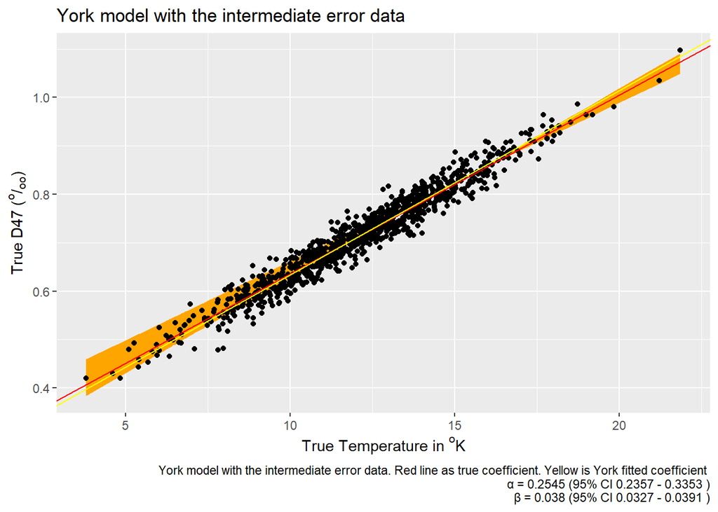

```r
createPlot(data_intermediate,
           york_result_intermediate,
           "York model with the intermediate error data",
           "York model with the intermediate error data. Red line as true coefficient. Yellow is York fitted coefficient")
```

### High error data

```r
york_result_high <- model(1234, York_model, data_high, D47~Temperature, 1000)

rbind(york_result_high) %>% kable()
```

|  | Median Intercept | Intercept Std. Error | 2.5% | 92.5% | Median Slope | Slope Std. Error | 2.5% | 92.5% | Median Train MSE | Median Test MSE |
| --- | --- | --- | --- | --- | --- | --- | --- | --- | --- | --- |
| york_result_high | 0.2396877 | 0.0007567 | 0.2271638 | 0.3371735 | 0.0390706 | 4.86e-05 | 0.0333651 | 0.0400675 | 0.0009677 | 0.0009648 |

#### Comparing result to the true parameters

Plot confident interval area of the median slope/intercept of bootstrapping results And comparing it to the true slope/intercept

I use the true data points to plot.

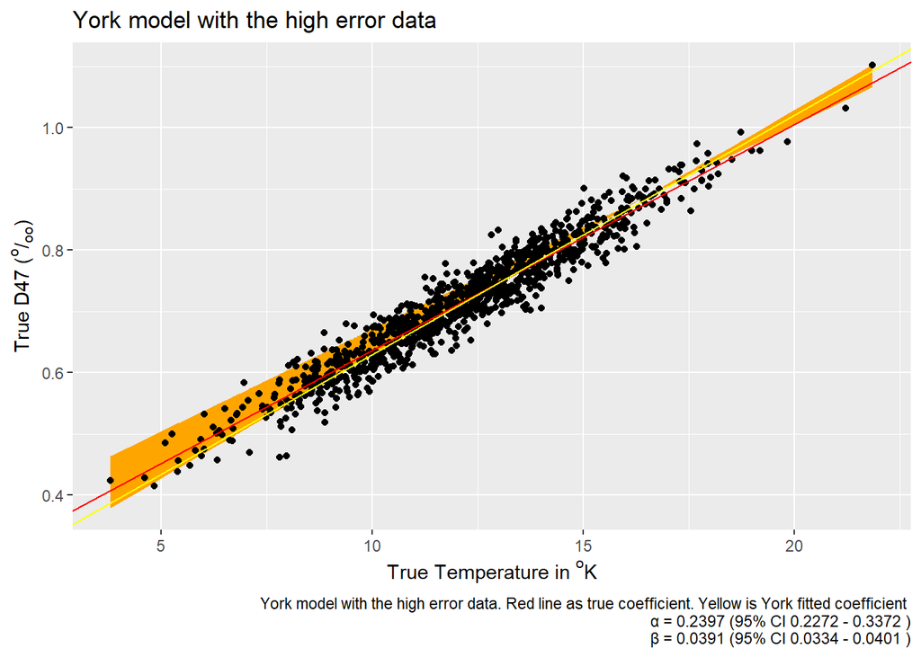

```r
createPlot(data_high,
           york_result_high,
           "York model with the high error data",
           "York model with the high error data. Red line as true coefficient. Yellow is York fitted coefficient")
```

## Median slopes/intercepts VS true parameters

```r
rbind(york_result_low, york_result_intermediate, york_result_high) %>% kable()
```

|  | Median Intercept | Intercept Std. Error | 2.5% | 92.5% | Median Slope | Slope Std. Error | 2.5% | 92.5% | Median Train MSE | Median Test MSE |
| --- | --- | --- | --- | --- | --- | --- | --- | --- | --- | --- |
| york_result_low | 0.2583409 | 0.0003717 | 0.2504001 | 0.3017510 | 0.0376571 | 2.41e-05 | 0.0349581 | 0.0382562 | 0.0001709 | 0.0001710 |
| york_result_intermediate | 0.2545176 | 0.0008533 | 0.2357275 | 0.3353030 | 0.0380324 | 5.45e-05 | 0.0326575 | 0.0391353 | 0.0006522 | 0.0006562 |
| york_result_high | 0.2396877 | 0.0007567 | 0.2271638 | 0.3371735 | 0.0390706 | 4.86e-05 | 0.0333651 | 0.0400675 | 0.0009677 | 0.0009648 |

## Deming Regression

Find the MLE line relating x and y when both are measured with error. When the variances of x and y are constant and equal, this is the special case of Deming regression.

### Low error data

```r
deming_result_low <- model(1234, Deming_model, data_low, D47~Temperature, 1000)

rbind(deming_result_low) %>% kable()
```

|  | Median Intercept | Intercept Std. Error | 2.5% | 92.5% | Median Slope | Slope Std. Error | 2.5% | 92.5% | Median Train MSE | Median Test MSE |
| --- | --- | --- | --- | --- | --- | --- | --- | --- | --- | --- |
| deming_result_low | 0.2583621 | 0.0003718 | 0.2505189 | 0.3018056 | 0.0376548 | 2.41e-05 | 0.0349638 | 0.0382497 | 0.000171 | 0.000171 |

#### Comparing result to the true parameters

Plot confident interval area of the median slope/intercept of bootstrapping results And comparing it to the true slope/intercept

I use the true data points to plot.

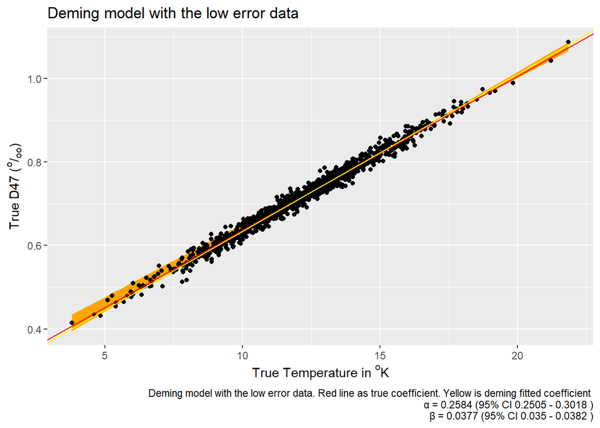

```r
createPlot(data_low,
           deming_result_low,
           "Deming model with the low error data",
           "Deming model with the low error data. Red line as true coefficient. Yellow is deming fitted coefficient")
```

### Intermediate error data

```r
deming_result_intermediate <- model(1234, Deming_model, data_intermediate, D47~Temperature, 1000)

rbind(deming_result_intermediate) %>% kable()
```

|  | Median Intercept | Intercept Std. Error | 2.5% | 92.5% | Median Slope | Slope Std. Error | 2.5% | 92.5% | Median Train MSE | Median Test MSE |
| --- | --- | --- | --- | --- | --- | --- | --- | --- | --- | --- |
| deming_result_intermediate | 0.2545605 | 0.0008535 | 0.2356724 | 0.3354301 | 0.0380295 | 5.45e-05 | 0.0326564 | 0.0391415 | 0.0006518 | 0.0006562 |

#### Comparing result to the true parameters

Plot confident interval area of the median slope/intercept of bootstrapping results And comparing it to the true slope/intercept

I use the true data points to plot.

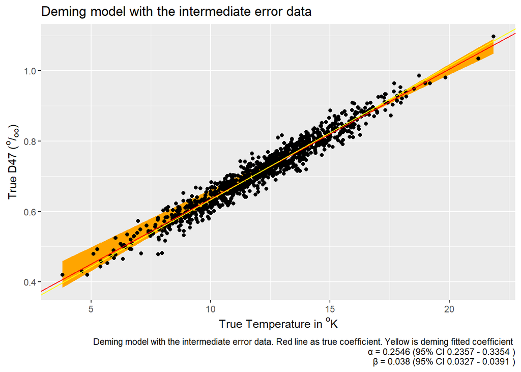

```r
createPlot(data_intermediate,
           deming_result_intermediate,
           "Deming model with the intermediate error data",
           "Deming model with the intermediate error data. Red line as true coefficient. Yellow is deming fitted coefficient")
```

### High error data

```r
deming_result_high <- model(1234, Deming_model, data_high, D47~Temperature, 1000)

rbind(deming_result_high) %>% kable()
```

|  | Median Intercept | Intercept Std. Error | 2.5% | 92.5% | Median Slope | Slope Std. Error | 2.5% | 92.5% | Median Train MSE | Median Test MSE |
| --- | --- | --- | --- | --- | --- | --- | --- | --- | --- | --- |
| deming_result_high | 0.2397284 | 0.0007571 | 0.2273222 | 0.3372984 | 0.0390686 | 4.86e-05 | 0.0333515 | 0.0400617 | 0.0009675 | 0.000965 |

#### Comparing result to the true parameters

Plot confident interval area of the median slope/intercept of bootstrapping results And comparing it to the true slope/intercept

I use the true data points to plot.

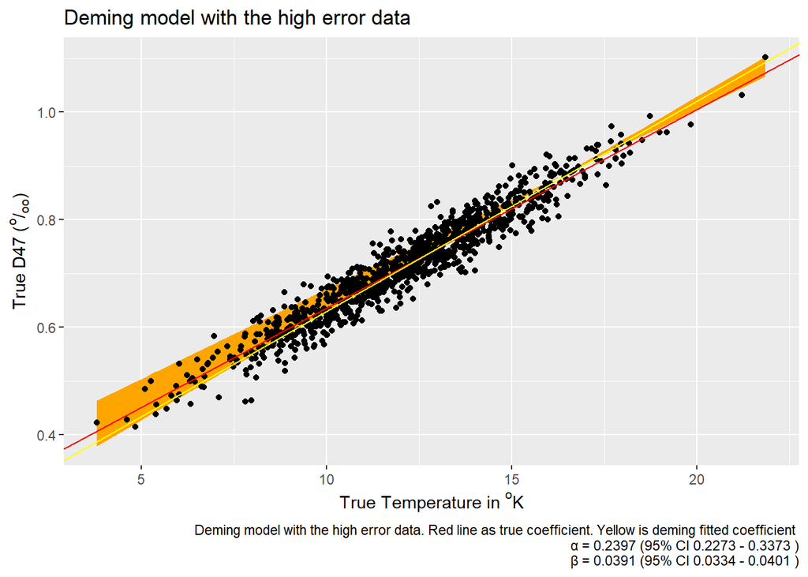

```r
createPlot(data_high,
           deming_result_high,
           "Deming model with the high error data",
           "Deming model with the high error data. Red line as true coefficient. Yellow is deming fitted coefficient")
```

## Median slopes/intercepts VS true parameters

```r
rbind(deming_result_low, deming_result_intermediate, deming_result_high) %>% kable()
```

|  | Median Intercept | Intercept Std. Error | 2.5% | 92.5% | Median Slope | Slope Std. Error | 2.5% | 92.5% | Median Train MSE | Median Test MSE |
| --- | --- | --- | --- | --- | --- | --- | --- | --- | --- | --- |
| deming_result_low | 0.2583621 | 0.0003718 | 0.2505189 | 0.3018056 | 0.0376548 | 2.41e-05 | 0.0349638 | 0.0382497 | 0.0001710 | 0.0001710 |
| deming_result_intermediate | 0.2545605 | 0.0008535 | 0.2356724 | 0.3354301 | 0.0380295 | 5.45e-05 | 0.0326564 | 0.0391415 | 0.0006518 | 0.0006562 |
| deming_result_high | 0.2397284 | 0.0007571 | 0.2273222 | 0.3372984 | 0.0390686 | 4.86e-05 | 0.0333515 | 0.0400617 | 0.0009675 | 0.0009650 |